# Applied Data Science Capstone - Bubble Tea Expansion

### Shuaib Shameem

For my capstone project, I wanted to explore a business problem I could hypothetically encounter with my current business.

#### Business Problem

As a bubble tea restaurant owner, I am looking to expand my business to new locations. I have seen success from my current location in Schaumburg, IL, and am looking to open a new location in one of Chicago's communities. Which of Chicago's communities could yield similar success for a new location?

#### Project Aims

This project will use demographics and businesses to identify communities in Chicago which are similar to the original location.

```python
#import and install libraries
import pandas as pd
import numpy as np

from geopy.geocoders import Nominatim

import requests

import matplotlib as mpl
import matplotlib.cm as cm
import matplotlib.colors as colors
import matplotlib.pyplot as plt

from sklearn import preprocessing
from sklearn.cluster import KMeans

!pip install folium --quiet
import folium

print("Libraries Installed and Imported")
```

```
Libraries Installed and Imported
```

## Data Collection

### Source 1

Data Source: CMAP Community Data Snapshots Raw Data, June 2019 Release

Table Name: Chicago Community Area (CCA) CDS data

Table Link: https://datahub.cmap.illinois.gov/dataset/1d2dd970-f0a6-4736-96a1-3caeb431f5e4/resource/8c4e096e-c90c-4bef-9cf1-9028d094296e/download/ReferenceCCAProfiles20132017.csv

Table Description: https://datahub.cmap.illinois.gov/dataset/1d2dd970-f0a6-4736-96a1-3caeb431f5e4/resource/d23fc5b1-0bb5-4bcc-bf70-688201534833/download/CDSFieldDescriptions201906.pdf

**Relevance: Contains the complete list of Chicago's Community Areas, along with the demographic data required (Population, Age, Education, Household Income)**

```python
CCA_table = pd.read_csv('https://datahub.cmap.illinois.gov/dataset/1d2dd970-f0a6-4736-96a1-3caeb431f5e4/resource/8c4e096e-c90c-4bef-9cf1-9028d094296e/download/ReferenceCCAProfiles20132017.csv')

columns = ['GEOG',
           'TOT_POP',
           'UND19','A20_34','A35_49','A50_64','A65_74','A75_84','OV85','MED_AGE',
           'LT_HS','HS','SOME_COLL','ASSOC','BACH','GRAD_PROF',
           'INC_LT_25K','INC_25_50K','INC_50_75K','INC_75_100K','INC_100_150K','INC_GT_150','MEDINC']

demo_df = pd.DataFrame(CCA_table,columns=columns)
demo_df.shape

# Label Explanation
# GEOG            - Community Area name
# TOT_POP         - Total Population

# Age Labels
# UND19           - 19 and under
# A20_34          - 20-34
# A35_49          - 35-49
# A50_64          - 50-64
# A65_74          - 65-74
# A75-84          - 75-84
# OV85            - 85 and older
# MED_AGE         - Median Age

# Education Attainment Labels
# LT_HS           - Less Than High School
# HS              - High School Diploma or Higher
# SOME_COLL       - Some College
# ASSOC           - Associate's Degree
# BACH            - Bachelor's Degree
# GRAD_PROF       - Graduate or Professional Degree

# Household Income Labels
# INC_LT_25K      - Less Than $25K
# INC_25_50K      - $25-50K
# INC_50_75K      - $50-75K
# INC_75_100K     - $75-100K
# INC_100_150K    - $100-150K
# INC_GT_150      - Greater Than $150K
# MEDINC          - Median Income
```

```
(77, 23)
```

### Source 2

Data Source: CMAP Community Data Snapshots Raw Data, June 2019 Release

Table Name: Municipality CDS data

Table Link: https://datahub.cmap.illinois.gov/dataset/1d2dd970-f0a6-4736-96a1-3caeb431f5e4/resource/bfeb1dd2-5e26-43d3-b758-0a42e64b7676/download/ReferencemuniProfiles20132017.csv

Table Description: https://datahub.cmap.illinois.gov/dataset/1d2dd970-f0a6-4736-96a1-3caeb431f5e4/resource/d23fc5b1-0bb5-4bcc-bf70-688201534833/download/CDSFieldDescriptions201906.pdf

**Relevance: Contains the required demographic data (Population, Age, Education, Household Income) for Schaumburg, IL**

```python
munic_table = pd.read_csv('https://datahub.cmap.illinois.gov/dataset/1d2dd970-f0a6-4736-96a1-3caeb431f5e4/resource/bfeb1dd2-5e26-43d3-b758-0a42e64b7676/download/ReferencemuniProfiles20132017.csv')

schaumburg_table = munic_table.iloc[230]
schaumburg_table = schaumburg_table[columns]

demo_df = demo_df.append(schaumburg_table,ignore_index=True)
demo_df.shape
```

```
(78, 23)
```

### Source 3

Data Source: OpenStreetMap API (via geopy)

**Relevance: Obtain lat/long coordinates for every location**

```python
geolocator = Nominatim(user_agent='Chi_explorer')
locations_df = pd.DataFrame()

for POI in demo_df['GEOG']:
    if POI == 'Schaumburg':
        address = 'Schaumburg, Illinois'
    else:
        address = POI + ', Chicago, Illinois'
    location = geolocator.geocode(address)
    locations_df = locations_df.append({'GEOG':POI,'lat':location.latitude,'long':location.longitude},ignore_index=True)
    print(address,': ',location.latitude,',',location.longitude)
```

```
Albany Park, Chicago, Illinois :  41.9719367 , -87.7161739
Archer Heights, Chicago, Illinois :  41.8114215 , -87.7261651
Armour Square, Chicago, Illinois :  41.8400333 , -87.633107
Ashburn, Chicago, Illinois :  41.7475332 , -87.7111628
Auburn Gresham, Chicago, Illinois :  41.750474 , -87.6643042
Austin, Chicago, Illinois :  41.8878759 , -87.7648508
Avalon Park, Chicago, Illinois :  41.7450346 , -87.5886584
Avondale, Chicago, Illinois :  41.9389208 , -87.711168
Belmont Cragin, Chicago, Illinois :  41.9316983 , -87.7686699
Beverly, Chicago, Illinois :  41.7181532 , -87.6717674
Bridgeport, Chicago, Illinois :  41.8379385 , -87.651028
Brighton Park, Chicago, Illinois :  41.8189217 , -87.6989421
Burnside, Chicago, Illinois :  41.7300345 , -87.596714
Calumet Heights, Chicago, Illinois :  41.7300347 , -87.5792134
Chatham, Chicago, Illinois :  41.7411454 , -87.6125481
Chicago Lawn, Chicago, Illinois :  41.7750332 , -87.6964408
Clearing, Chicago, Illinois :  41.780588 , -87.7733881
Douglas, Chicago, Illinois :  41.8348565 , -87.6179536
Dunning, Chicago, Illinois :  41.952809 , -87.7964493
East Garfield Park, Chicago, Illinois :  41.8808657 , -87.7028328
East Side, Chicago, Illinois :  41.6946178 , -87.5333872
Edgewater, Chicago, Illinois :  41.9833689 , -87.6639516
Edison Park, Chicago, Illinois :  42.0057335 , -87.8140036737589
Englewood, Chicago, Illinois :  41.7797559 , -87.6458836
Forest Glen, Chicago, Illinois :  41.99175155 , -87.7516732983677
Fuller Park, Chicago, Illinois :  41.8180891 , -87.6325508
Gage Park, Chicago, Illinois :  41.795033 , -87.6961636
Garfield Ridge, Chicago, Illinois :  41.8036171 , -87.7454915835633
Grand Boulevard, Chicago, Illinois :  41.8139226 , -87.6172724
Greater Grand Crossing, Chicago, Illinois :  41.76258065 , -87.6003196082787
Hegewisch, Chicago, Illinois :  41.6536462 , -87.5469885
Hermosa, Chicago, Illinois :  41.928643 , -87.7345019
Humboldt Park, Chicago, Illinois :  41.9057668 , -87.7041737
Hyde Park, Chicago, Illinois :  41.7942253 , -87.5925622437624
Irving Park, Chicago, Illinois :  41.953365 , -87.7364471
Jefferson Park, Chicago, Illinois :  41.9697375 , -87.7631179
Kenwood, Chicago, Illinois :  41.8091444 , -87.5979908
Lake View, Chicago, Illinois :  41.94705 , -87.6554287829005
Lincoln Park, Chicago, Illinois :  41.94029765 , -87.6381171054176
Lincoln Square, Chicago, Illinois :  41.94029765 , -87.6381171054176
```

[output cut: 23 more lines]

```
South Lawndale, Chicago, Illinois :  41.8436437 , -87.7125544
South Shore, Chicago, Illinois :  41.7626438 , -87.5751786179462
The Loop, Chicago, Illinois :  41.8788844 , -87.6271806173248
Uptown, Chicago, Illinois :  41.9666299 , -87.6555458
Washington Heights, Chicago, Illinois :  41.7064229 , -87.65616
Washington Park, Chicago, Illinois :  41.7925338 , -87.6181052
West Elsdon, Chicago, Illinois :  41.7939217 , -87.7244978
West Englewood, Chicago, Illinois :  41.7780891 , -87.6667177
West Garfield Park, Chicago, Illinois :  41.8805878 , -87.7292227
West Lawn, Chicago, Illinois :  41.7728107 , -87.722275
West Pullman, Chicago, Illinois :  41.6750456 , -87.637823
West Ridge, Chicago, Illinois :  42.0035482 , -87.6962426
West Town, Chicago, Illinois :  41.9014213 , -87.6861661
Woodlawn, Chicago, Illinois :  41.7794786 , -87.599493
Schaumburg, Illinois :  42.0333608 , -88.083406
```

```python
print(locations_df.shape)
locations_df.head()
```

```
(78, 3)
```

|  | GEOG | lat | long |
| --- | --- | --- | --- |
| 0 | Albany Park | 41.971937 | -87.716174 |
| 1 | Archer Heights | 41.811422 | -87.726165 |
| 2 | Armour Square | 41.840033 | -87.633107 |
| 3 | Ashburn | 41.747533 | -87.711163 |
| 4 | Auburn Gresham | 41.750474 | -87.664304 |

```python
latitude = 41.843
longitude = -87.808
map_chicagoland = folium.Map(location=[latitude, longitude],zoom_start=11)

for lat, lng, neighborhood in zip(locations_df['lat'], locations_df['long'], locations_df['GEOG']):
    label = folium.Popup(neighborhood, parse_html=True)
    folium.CircleMarker([lat,lng],
                       radius=5,
                       popup=label,
                       color='blue',
                       fill=True,
                       fill_color='#3186cc',
                       fill_opacity=0.7,
                       parse_html=False).add_to(map_chicagoland)

map_chicagoland
```

[interactive chart not shown]

### Source 4

Data Source: Foursquare (via Foursquare API)

**Relevance: Businesses near Areas of Interest**

```python
# @hidden cell
CLIENT_ID = 'IZAFYENE22QRBKRCBZPGCMOBNBJP0NI5QWW4VAGBZXFXLSPG'
CLIENT_SECRET = 'XZS5WIFHHMKO3HCQK4NV4TGVSDX4LBLMKWTRUXGWI15ZB3VJ'
VERSION = '20180605'
```

```python
def getNearbyVenues(names, latitudes, longitudes, radius=1500,LIMIT=100):
    i = 1
    venues_list=[]
    for name, lat, lng in zip(names, latitudes, longitudes):
        print(i, ': ', name)

        if name == 'Schaumburg':
            radius = 3300
        else:
            radius = 1500

        # create the API request URL
        url = 'https://api.foursquare.com/v2/venues/explore?&client_id={}&client_secret={}&v={}&ll={},{}&radius={}&limit={}'.format(
            CLIENT_ID,
            CLIENT_SECRET,
            VERSION,
            lat,
            lng,
            radius,
            LIMIT)

        # make the GET request
        response_code = 500
        while response_code != 200:                #reattempt GET request if server returns an error
            request_got = requests.get(url)
            response_code = request_got.status_code


        results = request_got.json()["response"]['groups'][0]['items']

        # return only relevant information for each nearby venue
        venues_list.append([(
            name,
            lat,
            lng,
            v['venue']['name'],
            v['venue']['location']['lat'],
            v['venue']['location']['lng'],
            v['venue']['categories'][0]['name']) for v in results])

        i = i+1

    nearby_venues = pd.DataFrame([item for venue_list in venues_list for item in venue_list])
    nearby_venues.columns = ['Neighbourhood',
                  'Neighbourhood Latitude',
                  'Neighbourhood Longitude',
                  'Venue',
                  'Venue Latitude',
                  'Venue Longitude',
                  'Venue Category']

    return(nearby_venues)
```

```python
chicago_venues = getNearbyVenues(names=locations_df['GEOG'],
                                 latitudes=locations_df['lat'],
                                 longitudes=locations_df['long'])
chicago_venues.groupby('Neighbourhood').count()
```

```
1 :  Albany Park
2 :  Archer Heights
3 :  Armour Square
4 :  Ashburn
5 :  Auburn Gresham
6 :  Austin
7 :  Avalon Park
8 :  Avondale
9 :  Belmont Cragin
10 :  Beverly
11 :  Bridgeport
12 :  Brighton Park
13 :  Burnside
14 :  Calumet Heights
15 :  Chatham
```

[output cut: 63 more lines]

| Neighbourhood | Neighbourhood Latitude | Neighbourhood Longitude | Venue | Venue Latitude | Venue Longitude | Venue Category |
| --- | --- | --- | --- | --- | --- | --- |
| Albany Park | 100 | 100 | 100 | 100 | 100 | 100 |
| Archer Heights | 64 | 64 | 64 | 64 | 64 | 64 |
| Armour Square | 100 | 100 | 100 | 100 | 100 | 100 |
| Ashburn | 62 | 62 | 62 | 62 | 62 | 62 |
| Auburn Gresham | 33 | 33 | 33 | 33 | 33 | 33 |
| Austin | 41 | 41 | 41 | 41 | 41 | 41 |
| Avalon Park | 80 | 80 | 80 | 80 | 80 | 80 |
| Avondale | 100 | 100 | 100 | 100 | 100 | 100 |
| Belmont Cragin | 94 | 94 | 94 | 94 | 94 | 94 |
| Beverly | 100 | 100 | 100 | 100 | 100 | 100 |
| Bridgeport | 100 | 100 | 100 | 100 | 100 | 100 |
| Brighton Park | 69 | 69 | 69 | 69 | 69 | 69 |
| Burnside | 75 | 75 | 75 | 75 | 75 | 75 |
| Calumet Heights | 82 | 82 | 82 | 82 | 82 | 82 |
| Chatham | 84 | 84 | 84 | 84 | 84 | 84 |
| Chicago Lawn | 71 | 71 | 71 | 71 | 71 | 71 |
| Clearing | 53 | 53 | 53 | 53 | 53 | 53 |
| Douglas | 100 | 100 | 100 | 100 | 100 | 100 |
| Dunning | 100 | 100 | 100 | 100 | 100 | 100 |
| East Garfield Park | 49 | 49 | 49 | 49 | 49 | 49 |
| East Side | 54 | 54 | 54 | 54 | 54 | 54 |
| Edgewater | 100 | 100 | 100 | 100 | 100 | 100 |
| Edison Park | 71 | 71 | 71 | 71 | 71 | 71 |
| Englewood | 30 | 30 | 30 | 30 | 30 | 30 |
| Forest Glen | 53 | 53 | 53 | 53 | 53 | 53 |
| Fuller Park | 57 | 57 | 57 | 57 | 57 | 57 |
| Gage Park | 66 | 66 | 66 | 66 | 66 | 66 |
| Garfield Ridge | 62 | 62 | 62 | 62 | 62 | 62 |
| Grand Boulevard | 80 | 80 | 80 | 80 | 80 | 80 |
| Greater Grand Crossing | 48 | 48 | 48 | 48 | 48 | 48 |
| ... | ... | ... | ... | ... | ... | ... |
| Near West Side | 100 | 100 | 100 | 100 | 100 | 100 |
| New City | 38 | 38 | 38 | 38 | 38 | 38 |
| North Center | 100 | 100 | 100 | 100 | 100 | 100 |
| North Lawndale | 57 | 57 | 57 | 57 | 57 | 57 |
| North Park | 89 | 89 | 89 | 89 | 89 | 89 |
| Norwood Park | 58 | 58 | 58 | 58 | 58 | 58 |
| O'Hare | 90 | 90 | 90 | 90 | 90 | 90 |
| Oakland | 65 | 65 | 65 | 65 | 65 | 65 |
| Portage Park | 100 | 100 | 100 | 100 | 100 | 100 |
| Pullman | 23 | 23 | 23 | 23 | 23 | 23 |
| Riverdale | 9 | 9 | 9 | 9 | 9 | 9 |
| Rogers Park | 100 | 100 | 100 | 100 | 100 | 100 |
| Roseland | 42 | 42 | 42 | 42 | 42 | 42 |
| Schaumburg | 100 | 100 | 100 | 100 | 100 | 100 |
| South Chicago | 32 | 32 | 32 | 32 | 32 | 32 |
| South Deering | 7 | 7 | 7 | 7 | 7 | 7 |
| South Lawndale | 75 | 75 | 75 | 75 | 75 | 75 |
| South Shore | 65 | 65 | 65 | 65 | 65 | 65 |
| The Loop | 100 | 100 | 100 | 100 | 100 | 100 |
| Uptown | 100 | 100 | 100 | 100 | 100 | 100 |
| Washington Heights | 24 | 24 | 24 | 24 | 24 | 24 |
| Washington Park | 61 | 61 | 61 | 61 | 61 | 61 |
| West Elsdon | 79 | 79 | 79 | 79 | 79 | 79 |
| West Englewood | 34 | 34 | 34 | 34 | 34 | 34 |
| West Garfield Park | 41 | 41 | 41 | 41 | 41 | 41 |
| West Lawn | 53 | 53 | 53 | 53 | 53 | 53 |
| West Pullman | 38 | 38 | 38 | 38 | 38 | 38 |
| West Ridge | 77 | 77 | 77 | 77 | 77 | 77 |
| West Town | 100 | 100 | 100 | 100 | 100 | 100 |
| Woodlawn | 61 | 61 | 61 | 61 | 61 | 61 |

78 rows × 6 columns

## Data Processing

### Clustering Neighborhoods Based on Nearby Common Venue Types

Extracting venue type frequency from our list of venues, grouped on their neighborhood

```python
chicago_onehot = pd.get_dummies(chicago_venues[['Venue Category']], prefix="", prefix_sep="")
chicago_onehot['Neighbourhood'] = chicago_venues['Neighbourhood']
fixed_columns = [chicago_onehot.columns[-1]] + list(chicago_onehot.columns[:-1])
chicago_onehot = chicago_onehot[fixed_columns]
chicago_onehot.head()
```

|  | Neighbourhood | ATM | Accessories Store | Adult Boutique | Afghan Restaurant | African Restaurant | Airport | Airport Food Court | Airport Gate | Airport Lounge | ... | Warehouse Store | Waste Facility | Waterfront | Weight Loss Center | Whisky Bar | Wine Bar | Wine Shop | Wings Joint | Women's Store | Yoga Studio |
| --- | --- | --- | --- | --- | --- | --- | --- | --- | --- | --- | --- | --- | --- | --- | --- | --- | --- | --- | --- | --- | --- |
| 0 | Albany Park | 0 | 0 | 0 | 0 | 0 | 0 | 0 | 0 | 0 | ... | 0 | 0 | 0 | 0 | 0 | 0 | 0 | 0 | 0 | 0 |
| 1 | Albany Park | 0 | 0 | 0 | 0 | 0 | 0 | 0 | 0 | 0 | ... | 0 | 0 | 0 | 0 | 0 | 0 | 0 | 0 | 0 | 0 |
| 2 | Albany Park | 0 | 0 | 0 | 0 | 0 | 0 | 0 | 0 | 0 | ... | 0 | 0 | 0 | 0 | 0 | 0 | 0 | 0 | 0 | 0 |
| 3 | Albany Park | 0 | 0 | 0 | 0 | 0 | 0 | 0 | 0 | 0 | ... | 0 | 0 | 0 | 0 | 0 | 0 | 0 | 0 | 0 | 0 |
| 4 | Albany Park | 0 | 0 | 0 | 0 | 0 | 0 | 0 | 0 | 0 | ... | 0 | 0 | 0 | 0 | 0 | 0 | 0 | 0 | 0 | 0 |

5 rows × 362 columns

```python
chicago_grouped = chicago_onehot.groupby('Neighbourhood').mean().reset_index()
chicago_grouped.shape
```

```
(78, 362)
```

Extracting the 10 most common venue types for use in clustering

```python
def return_most_common_venues(row, num_top_venues):
    row_categories = row.iloc[1:]
    row_categories_sorted = row_categories.sort_values(ascending=False)

    return row_categories_sorted.index.values[0:num_top_venues]
```

```python
num_top_venues = 10
indicators = ['st','nd','rd']

columns=['Neighbourhood']
for index in np.arange(num_top_venues):
    try:
        columns.append('{}{} Most Common Venue'.format(index+1, indicators[index]))
    except:
        columns.append('{}th Most Common Venue'.format(index+1))

chicago_venues_sorted = pd.DataFrame(columns=columns)
chicago_venues_sorted['Neighbourhood'] = chicago_grouped['Neighbourhood']

for index in np.arange(chicago_grouped.shape[0]):
    chicago_venues_sorted.iloc[index, 1:] = return_most_common_venues(chicago_grouped.iloc[index, :], num_top_venues)

chicago_venues_sorted.head()
```

|  | Neighbourhood | 1st Most Common Venue | 2nd Most Common Venue | 3rd Most Common Venue | 4th Most Common Venue | 5th Most Common Venue | 6th Most Common Venue | 7th Most Common Venue | 8th Most Common Venue | 9th Most Common Venue | 10th Most Common Venue |
| --- | --- | --- | --- | --- | --- | --- | --- | --- | --- | --- | --- |
| 0 | Albany Park | Pizza Place | Coffee Shop | Korean Restaurant | Chinese Restaurant | Mexican Restaurant | Sandwich Place | Park | Grocery Store | Middle Eastern Restaurant | Asian Restaurant |
| 1 | Archer Heights | Mexican Restaurant | Sandwich Place | Mobile Phone Shop | Bank | Discount Store | Bar | Storage Facility | Fast Food Restaurant | Seafood Restaurant | Donut Shop |
| 2 | Armour Square | Chinese Restaurant | Bar | Pizza Place | Sandwich Place | Park | Bakery | Shipping Store | Hot Dog Joint | Mexican Restaurant | Wings Joint |
| 3 | Ashburn | Park | Pizza Place | Intersection | Liquor Store | Ice Cream Shop | Seafood Restaurant | Mexican Restaurant | Fast Food Restaurant | American Restaurant | Bakery |
| 4 | Auburn Gresham | Discount Store | Intersection | Pharmacy | Park | Fast Food Restaurant | Seafood Restaurant | Fried Chicken Joint | Grocery Store | Greek Restaurant | Gas Station |

Utilizing the Elbow Method to determine the most efficient number of clusters for K-Means

```python
distortions = []
for i in range(1,20):
    km = KMeans(
        n_clusters = i, init='random',
        n_init=10, max_iter=300,
        random_state=0)
    km.fit(chicago_grouped.drop('Neighbourhood',1))
    distortions.append(km.inertia_)
```

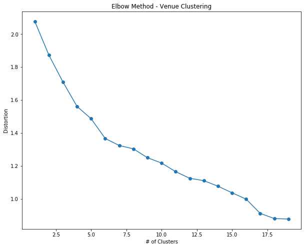

```python
plt.figure(figsize=(10,8))
plt.ylabel('Distortion')
plt.xlabel('# of Clusters')
plt.title('Elbow Method - Venue Clustering')
plt.plot(range(1,20), distortions, marker='o')
plt.show()
```

No clear elbow, but distortion falls below 1 around 16 clusters, and there is a minor elbow around 17 & 18 clusters.

Clustering on Venue Frequency

```python
kclusters = 17

chicago_grouped_clustering = chicago_grouped.drop('Neighbourhood',1)

kmeans = KMeans(n_clusters = kclusters, random_state = 0).fit(chicago_grouped_clustering)

kmeans.labels_[0:10]
```

```
array([ 7,  2,  7,  7, 13, 15,  8,  4,  2,  8], dtype=int32)
```

```python
try:
    chicago_venues_sorted.insert(0, 'Cluster Labels', kmeans.labels_)
except:
    chicago_venues_sorted['Cluster Labels'] = kmeans.labels_

chicago_merged = locations_df

chicago_merged = chicago_merged.set_index('GEOG').join(chicago_venues_sorted.set_index('Neighbourhood'),how='right')

chicago_merged.head()
```

| Neighbourhood | lat | long | Cluster Labels | 1st Most Common Venue | 2nd Most Common Venue | 3rd Most Common Venue | 4th Most Common Venue | 5th Most Common Venue | 6th Most Common Venue | 7th Most Common Venue | 8th Most Common Venue | 9th Most Common Venue | 10th Most Common Venue |
| --- | --- | --- | --- | --- | --- | --- | --- | --- | --- | --- | --- | --- | --- |
| Albany Park | 41.971937 | -87.716174 | 7 | Pizza Place | Coffee Shop | Korean Restaurant | Chinese Restaurant | Mexican Restaurant | Sandwich Place | Park | Grocery Store | Middle Eastern Restaurant | Asian Restaurant |
| Archer Heights | 41.811422 | -87.726165 | 2 | Mexican Restaurant | Sandwich Place | Mobile Phone Shop | Bank | Discount Store | Bar | Storage Facility | Fast Food Restaurant | Seafood Restaurant | Donut Shop |
| Armour Square | 41.840033 | -87.633107 | 7 | Chinese Restaurant | Bar | Pizza Place | Sandwich Place | Park | Bakery | Shipping Store | Hot Dog Joint | Mexican Restaurant | Wings Joint |
| Ashburn | 41.747533 | -87.711163 | 7 | Park | Pizza Place | Intersection | Liquor Store | Ice Cream Shop | Seafood Restaurant | Mexican Restaurant | Fast Food Restaurant | American Restaurant | Bakery |
| Auburn Gresham | 41.750474 | -87.664304 | 13 | Discount Store | Intersection | Pharmacy | Park | Fast Food Restaurant | Seafood Restaurant | Fried Chicken Joint | Grocery Store | Greek Restaurant | Gas Station |

Map of communities, color-coded to their cluster

```python
latitude = 41.843
longitude = -87.808
map_clusters = folium.Map(location=[latitude, longitude],zoom_start=11)

x = np.arange(kclusters)
ys = [i + x + (i*x)**2 for i in range(kclusters)]
colors_array = cm.rainbow(np.linspace(0,1, len(ys)))
rainbow = [colors.rgb2hex(i) for i in colors_array]

markers_colors = []
for lat, lng, neighborhood, cluster in zip(chicago_merged['lat'], chicago_merged['long'], chicago_merged.index.array, chicago_merged['Cluster Labels']):
    label = folium.Popup(str(neighborhood) + ', Cluster ' + str(cluster), parse_html=True)
    folium.CircleMarker([lat,lng],
                       radius=5,
                       popup=label,
                       color=rainbow[cluster-1],
                       fill=True,
                       fill_color=rainbow[cluster-1],
                       fill_opacity=0.7,
                       parse_html=False).add_to(map_clusters)

map_clusters
```

[interactive chart not shown]

Extracting data for only the communities which are clustered with Schaumburg

```python
schaumburg_cluster = chicago_venues_sorted.loc[chicago_venues_sorted['Neighbourhood'] == 'Schaumburg']['Cluster Labels']
schaumburg_cluster = schaumburg_cluster.reset_index().drop('index',1)
schaumburg_cluster = schaumburg_cluster['Cluster Labels'].get(0)
similar_areas = chicago_venues_sorted.loc[chicago_venues_sorted['Cluster Labels'] == schaumburg_cluster]
similar_areas.head(20)
```

|  | Cluster Labels | Neighbourhood | 1st Most Common Venue | 2nd Most Common Venue | 3rd Most Common Venue | 4th Most Common Venue | 5th Most Common Venue | 6th Most Common Venue | 7th Most Common Venue | 8th Most Common Venue | 9th Most Common Venue | 10th Most Common Venue |
| --- | --- | --- | --- | --- | --- | --- | --- | --- | --- | --- | --- | --- |
| 7 | 4 | Avondale | Bar | Italian Restaurant | Grocery Store | Coffee Shop | Café | Mexican Restaurant | Park | Cocktail Bar | Art Gallery | Bookstore |
| 21 | 4 | Edgewater | Coffee Shop | Italian Restaurant | Mexican Restaurant | Asian Restaurant | Sandwich Place | Breakfast Spot | Vietnamese Restaurant | Grocery Store | Sushi Restaurant | Burger Joint |
| 22 | 4 | Edison Park | Italian Restaurant | Coffee Shop | Sandwich Place | Park | Salon / Barbershop | Pizza Place | Donut Shop | Spa | Bar | Mexican Restaurant |
| 37 | 4 | Lake View | Pizza Place | Italian Restaurant | Gay Bar | Sandwich Place | Sports Bar | Gym | American Restaurant | Coffee Shop | General Entertainment | Vegetarian / Vegan Restaurant |
| 38 | 4 | Lincoln Park | Mexican Restaurant | Sushi Restaurant | Bakery | Coffee Shop | Vegetarian / Vegan Restaurant | Asian Restaurant | Grocery Store | Italian Restaurant | Gay Bar | Bar |
| 39 | 4 | Lincoln Square | Mexican Restaurant | Sushi Restaurant | Bakery | Coffee Shop | Vegetarian / Vegan Restaurant | Asian Restaurant | Grocery Store | Italian Restaurant | Gay Bar | Bar |
| 40 | 4 | Logan Square | Cocktail Bar | Coffee Shop | Café | Bar | Mexican Restaurant | Latin American Restaurant | Brewery | Pizza Place | Park | Ice Cream Shop |
| 46 | 4 | Near North Side | Hotel | Gym | Steakhouse | Salon / Barbershop | American Restaurant | Italian Restaurant | New American Restaurant | Coffee Shop | Pizza Place | Bar |
| 47 | 4 | Near South Side | Chinese Restaurant | Park | Asian Restaurant | Bakery | Burger Joint | Pizza Place | Grocery Store | Yoga Studio | Italian Restaurant | Sculpture Garden |
| 48 | 4 | Near West Side | Italian Restaurant | Pizza Place | Coffee Shop | Yoga Studio | Breakfast Spot | Brewery | Sandwich Place | Café | Park | Deli / Bodega |
| 50 | 4 | North Center | Bar | Pizza Place | Coffee Shop | Brewery | Gym | Italian Restaurant | Mexican Restaurant | Dive Bar | Thai Restaurant | Pub |
| 54 | 4 | O'Hare | Coffee Shop | Airport Lounge | Snack Place | American Restaurant | Mexican Restaurant | Airport Service | Tea Room | Chocolate Shop | Sushi Restaurant | Asian Restaurant |
| 59 | 4 | Rogers Park | Beach | Sandwich Place | Mexican Restaurant | Pizza Place | Café | Fast Food Restaurant | Park | African Restaurant | Bakery | Bar |
| 61 | 4 | Schaumburg | Fast Food Restaurant | Grocery Store | Hotel | Hookah Bar | Pizza Place | Gym | Coffee Shop | Bakery | Korean Restaurant | Bookstore |
| 66 | 4 | The Loop | Theater | Coffee Shop | Hotel | Park | Pizza Place | Museum | Snack Place | Bakery | Sandwich Place | Salad Place |
| 67 | 4 | Uptown | Vietnamese Restaurant | Coffee Shop | Sushi Restaurant | Chinese Restaurant | Mexican Restaurant | Park | Grocery Store | Bar | Thai Restaurant | Breakfast Spot |
| 76 | 4 | West Town | Coffee Shop | Pizza Place | Restaurant | Bar | Sushi Restaurant | Café | Bakery | Dive Bar | New American Restaurant | Deli / Bodega |

```python
similar_areas_list = similar_areas[['Neighbourhood']]
similar_areas_list.set_index('Neighbourhood')
```

| Neighbourhood |
| --- |
| Avondale |
| Edgewater |
| Edison Park |
| Lake View |
| Lincoln Park |
| Lincoln Square |
| Logan Square |
| Near North Side |
| Near South Side |
| Near West Side |
| North Center |
| O'Hare |
| Rogers Park |
| Schaumburg |
| The Loop |
| Uptown |
| West Town |

### Visualizing Demographics on Venue Clustered Neighborhoods

Retrieving demographics for communities in the same cluster as Schaumburg

```python
demo_similar = demo_df[demo_df['GEOG'].isin(list(similar_areas_list['Neighbourhood']))]
demo_similar.reset_index(inplace=True)
demo_similar = demo_similar.drop('index',1)
demo_similar.head()
```

|  | GEOG | TOT_POP | UND19 | A20_34 | A35_49 | A50_64 | A65_74 | A75_84 | OV85 | MED_AGE | ... | ASSOC | BACH | GRAD_PROF | INC_LT_25K | INC_25_50K | INC_50_75K | INC_75_100K | INC_100_150K | INC_GT_150 | MEDINC |
| --- | --- | --- | --- | --- | --- | --- | --- | --- | --- | --- | --- | --- | --- | --- | --- | --- | --- | --- | --- | --- | --- |
| 0 | Avondale | 37368 | 8556 | 12291 | 7847 | 4977 | 2228 | 1016 | 453 | 32.723158 | ... | 1406 | 5518 | 3170 | 2985 | 3517 | 2337 | 1570 | 1631 | 1295 | 51702.67490 |
| 1 | Edgewater | 55965 | 7955 | 16230 | 12495 | 11106 | 4765 | 2238 | 1176 | 39.022775 | ... | 2178 | 14162 | 10496 | 7767 | 6835 | 5030 | 2921 | 3301 | 3036 | 49287.01181 |
| 2 | Edison Park | 11605 | 2689 | 2333 | 2656 | 2129 | 861 | 629 | 308 | 40.447977 | ... | 531 | 2393 | 1629 | 441 | 784 | 476 | 605 | 886 | 1380 | 99194.21488 |
| 3 | Lake View | 100470 | 11988 | 49608 | 19828 | 10963 | 4803 | 2344 | 936 | 31.167780 | ... | 2560 | 36314 | 24283 | 6891 | 7897 | 8543 | 6841 | 10038 | 12537 | 86118.62301 |
| 4 | Lincoln Park | 67710 | 12007 | 30048 | 11461 | 8089 | 3743 | 1828 | 534 | 30.234775 | ... | 884 | 23293 | 16704 | 4659 | 3361 | 4783 | 3408 | 5749 | 10376 | 99684.56573 |

5 rows × 23 columns

Normalizing Data

```python
age_columns = ['UND19','A20_34','A35_49','A50_64','A65_74','A75_84','OV85']
edu_columns = ['LT_HS','HS','SOME_COLL','ASSOC','BACH','GRAD_PROF']
inc_columns = ['INC_LT_25K','INC_25_50K','INC_50_75K','INC_75_100K','INC_100_150K','INC_GT_150']
```

```python
demo_similar['age_total']=demo_similar.loc[:,age_columns].sum(axis=1)
demo_similar['edu_total']=demo_similar.loc[:,edu_columns].sum(axis=1)
demo_similar['inc_total']=demo_similar.loc[:,inc_columns].sum(axis=1)
demo_similar.loc[:,age_columns] = demo_similar.loc[:,age_columns].div(demo_similar.age_total,axis=0)
demo_similar.loc[:,edu_columns] = demo_similar.loc[:,edu_columns].div(demo_similar.edu_total,axis=0)
demo_similar.loc[:,inc_columns] = demo_similar.loc[:,inc_columns].div(demo_similar.inc_total,axis=0)
demo_similar.shape
```

```
(17, 26)
```

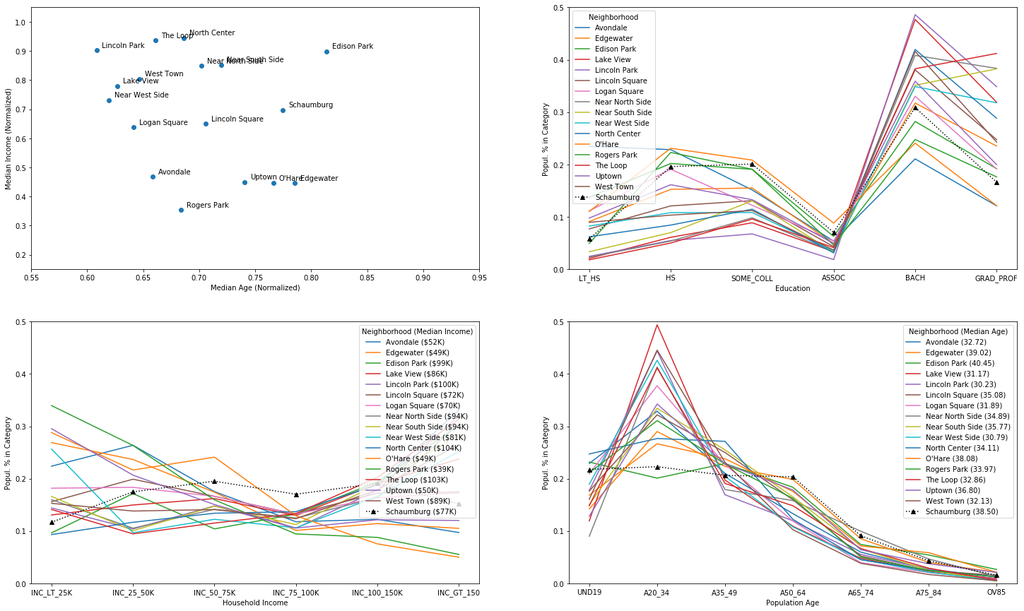

```python
age_ticks = [0,1,2,3,4,5,6]
edu_ticks = [0,1,2,3,4,5]
inc_ticks = [0,1,2,3,4,5]

plt.figure(figsize=(25,15))

plt.subplot(2,2,1)

x_val = (demo_similar['MED_AGE'].div(demo_df['MED_AGE'].max()))
y_val = (demo_similar['MEDINC'].div(demo_df['MEDINC'].max()))
plt.scatter(x_val,y_val)
plt.xlim(0.55,0.95)
plt.ylim(0.15,1.05)
plt.ylabel('Median Income (Normalized)')
plt.xlabel('Median Age (Normalized)')
for x, y, name in zip(x_val, y_val, demo_similar.GEOG):
    plt.annotate(name, (x + 0.005, y + .01))



plt.subplot(2,2,2)

for index, row in demo_similar.iterrows():
    plt.xticks(edu_ticks, edu_columns)
    if row['GEOG'] == 'Schaumburg':
        plt.plot(row[edu_columns],'^k:',label=row['GEOG'])
    else:
        plt.plot(row[edu_columns],label=row['GEOG'])
plt.ylim(0,0.5)
plt.ylabel('Popul. % in Category')
plt.xlabel('Education')
plt.legend(title='Neighborhood')

plt.subplot(2,2,3)

for index, row in demo_similar.iterrows():
    plt.xticks(inc_ticks, inc_columns)
    short = row['MEDINC'] / 1000
    label = '{} (${:0.0f}K)'.format(row['GEOG'],short)
    if row['GEOG'] == 'Schaumburg':
        plt.plot(row[inc_columns],'^k:',label=label)
    else:
        plt.plot(row[inc_columns],label=label)
plt.ylim(0,0.5)
plt.ylabel('Popul. % in Category')
plt.xlabel('Household Income')
plt.legend(title='Neighborhood (Median Income)')

plt.subplot(2,2,4)

for index, row in demo_similar.iterrows():
    plt.xticks(age_ticks, age_columns)
    label = '{} ({:.2f})'.format(row['GEOG'],row['MED_AGE'])
    if row['GEOG'] == 'Schaumburg':
        plt.plot(row[age_columns],'^k:',label=label)
    else:
        plt.plot(row[age_columns],label=label)
plt.ylim(0,0.5)
plt.ylabel('Popul. % in Category')
plt.xlabel('Population Age')
plt.legend(title='Neighborhood (Median Age)')

plt.show()
```

### Clustering Neighborhoods Based on Demographics

```python
demo_no_median = demo_df.drop(['MED_AGE','MEDINC','TOT_POP'],1)
demo_clustering = demo_no_median.drop(['GEOG'],1)
```

Utilizing the Elbow Method to determine the most efficient number of clusters for K-Means

```python
distortions_2 = []
for i in range(1,25):
    km = KMeans(
        n_clusters = i, init='random',
        n_init=10, max_iter=300,
        random_state=0)
    km.fit(demo_clustering)
    distortions_2.append(km.inertia_)
```

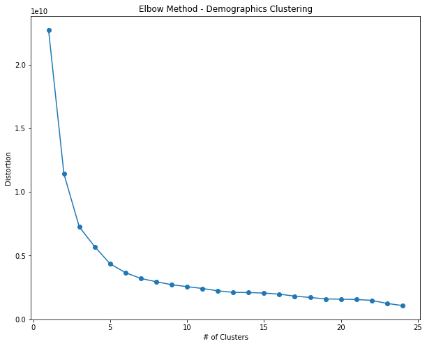

```python
plt.figure(figsize=(10,8))
plt.ylabel('Distortion')
plt.xlabel('# of Clusters')
plt.title('Elbow Method - Demographics Clustering')
plt.plot(range(1,25), distortions_2, marker='o')
plt.show()
```

Again, no clear elbow, but 5 clusters seems to be a good balance

Clustering on Demographics

```python
kclusters = 5

kmeans = KMeans(n_clusters = kclusters, random_state = 0).fit(demo_clustering)


try:
    demo_no_median.insert(0, 'Cluster Labels', kmeans.labels_)
except:
    demo_no_median['Cluster Labels'] = kmeans.labels_

schaumburg_cluster = demo_no_median.loc[demo_no_median['GEOG'] == 'Schaumburg']['Cluster Labels']
schaumburg_cluster = schaumburg_cluster.reset_index().drop('index',1)
schaumburg_cluster = schaumburg_cluster['Cluster Labels'].get(0)

demo_similar_2 = demo_no_median.loc[demo_no_median['Cluster Labels'] == schaumburg_cluster]
demo_similar_2.head(15)
```

|  | Cluster Labels | GEOG | UND19 | A20_34 | A35_49 | A50_64 | A65_74 | A75_84 | OV85 | LT_HS | ... | SOME_COLL | ASSOC | BACH | GRAD_PROF | INC_LT_25K | INC_25_50K | INC_50_75K | INC_75_100K | INC_100_150K | INC_GT_150 |
| --- | --- | --- | --- | --- | --- | --- | --- | --- | --- | --- | --- | --- | --- | --- | --- | --- | --- | --- | --- | --- | --- |
| 21 | 3 | Edgewater | 7955 | 16230 | 12495 | 11106 | 4765 | 2238 | 1176 | 4060 | ... | 6919 | 2178 | 14162 | 10496 | 7767 | 6835 | 5030 | 2921 | 3301 | 3036 |
| 34 | 3 | Irving Park | 12532 | 14033 | 13144 | 9747 | 3050 | 1590 | 510 | 5612 | ... | 6791 | 2346 | 10054 | 5145 | 3207 | 5240 | 3792 | 2517 | 2778 | 2702 |
| 39 | 3 | Lincoln Square | 7356 | 13432 | 10428 | 6664 | 2179 | 999 | 657 | 2485 | ... | 4227 | 1387 | 12292 | 7990 | 2854 | 3640 | 3041 | 2417 | 3152 | 3192 |
| 40 | 3 | Logan Square | 15288 | 27569 | 16595 | 8685 | 2888 | 1509 | 512 | 5814 | ... | 6370 | 2808 | 17246 | 9992 | 5302 | 5352 | 4846 | 3862 | 4769 | 5040 |
| 48 | 3 | Near West Side | 11897 | 26796 | 12859 | 6779 | 2876 | 1339 | 326 | 3492 | ... | 4590 | 1476 | 14801 | 13486 | 7225 | 2724 | 3447 | 2990 | 4680 | 7096 |
| 56 | 3 | Portage Park | 14715 | 14580 | 13626 | 13573 | 4305 | 2453 | 1056 | 6870 | ... | 8748 | 3569 | 8452 | 4420 | 4257 | 4704 | 4586 | 3147 | 3322 | 2673 |
| 59 | 3 | Rogers Park | 11632 | 17116 | 12560 | 8945 | 2757 | 1363 | 689 | 5231 | ... | 7262 | 1752 | 9434 | 6712 | 8179 | 6346 | 3843 | 2275 | 2115 | 1330 |
| 65 | 3 | The Loop | 5318 | 14755 | 6846 | 5317 | 2387 | 1043 | 214 | 486 | ... | 2600 | 1119 | 10390 | 11181 | 2712 | 1817 | 2213 | 2564 | 3892 | 6018 |
| 66 | 3 | Uptown | 7430 | 19857 | 13238 | 10339 | 3723 | 2170 | 1216 | 4499 | ... | 6113 | 2270 | 16537 | 9191 | 8667 | 6067 | 4416 | 3100 | 3565 | 3526 |
| 74 | 3 | West Ridge | 20756 | 17065 | 15001 | 13648 | 5461 | 2914 | 1370 | 8914 | ... | 7979 | 2776 | 12747 | 7506 | 5889 | 6740 | 4217 | 2675 | 3279 | 2394 |
| 77 | 3 | Schaumburg | 16200 | 16589 | 15359 | 15142 | 6768 | 3208 | 1161 | 3175 | ... | 11044 | 3865 | 16990 | 9137 | 3560 | 5327 | 5945 | 5187 | 5817 | 4624 |

11 rows × 21 columns

### Visualizing Demographics of Demographically Clustered Neighborhoods

```python
medians = demo_df.loc[demo_df['GEOG'].isin(demo_similar_2['GEOG'])][['MEDINC','MED_AGE','TOT_POP']]

demo_similar_2['age_total']=demo_similar_2.loc[:,age_columns].sum(axis=1)
demo_similar_2['edu_total']=demo_similar_2.loc[:,edu_columns].sum(axis=1)
demo_similar_2['inc_total']=demo_similar_2.loc[:,inc_columns].sum(axis=1)

demo_similar_2.loc[:,age_columns] = demo_similar_2.loc[:,age_columns].div(demo_similar_2.age_total,axis=0)
demo_similar_2.loc[:,edu_columns] = demo_similar_2.loc[:,edu_columns].div(demo_similar_2.edu_total,axis=0)
demo_similar_2.loc[:,inc_columns] = demo_similar_2.loc[:,inc_columns].div(demo_similar_2.inc_total,axis=0)

demo_similar_2.shape
```

```
(11, 24)
```

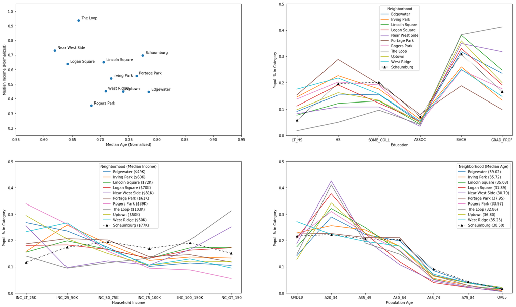

```python
plt.figure(figsize=(25,15))

plt.subplot(2,2,1)

x_val = (medians['MED_AGE'].div(demo_df['MED_AGE'].max()))
y_val = (medians['MEDINC'].div(demo_df['MEDINC'].max()))
plt.scatter(x_val,y_val)
plt.xlim(0.55,0.95)
plt.ylim(0.15,1.05)
plt.ylabel('Median Income (Normalized)')
plt.xlabel('Median Age (Normalized)')
for x, y, name in zip(x_val, y_val, demo_similar_2.GEOG):
    plt.annotate(name, (x + 0.005, y + .01))



plt.subplot(2,2,2)

for index, row in demo_similar_2.iterrows():
    plt.xticks(edu_ticks, edu_columns)
    if row['GEOG'] == 'Schaumburg':
        plt.plot(row[edu_columns],'^k:',label=row['GEOG'])
    else:
        plt.plot(row[edu_columns],label=row['GEOG'])
plt.ylim(0,0.5)
plt.ylabel('Popul. % in Category')
plt.xlabel('Education')
plt.legend(title='Neighborhood')

plt.subplot(2,2,3)

for index, row in demo_similar_2.iterrows():
    plt.xticks(inc_ticks, inc_columns)
    short = medians.loc[index]['MEDINC'] / 1000
    label = '{} (${:0.0f}K)'.format(row['GEOG'],short)
    if row['GEOG'] == 'Schaumburg':
        plt.plot(row[inc_columns],'^k:',label=label)
    else:
        plt.plot(row[inc_columns],label=label)
plt.ylim(0,0.5)
plt.ylabel('Popul. % in Category')
plt.xlabel('Household Income')
plt.legend(title='Neighborhood (Median Income)')

plt.subplot(2,2,4)

for index, row in demo_similar_2.iterrows():
    plt.xticks(age_ticks, age_columns)
    label = '{} ({:.2f})'.format(row['GEOG'],medians.loc[index]['MED_AGE'])
    if row['GEOG'] == 'Schaumburg':
        plt.plot(row[age_columns],'^k:',label=label)
    else:
        plt.plot(row[age_columns],label=label)
plt.ylim(0,0.5)
plt.ylabel('Popul. % in Category')
plt.xlabel('Population Age')
plt.legend(title='Neighborhood (Median Age)')

plt.show()
```

## Data Analysis

### Data and Visualizations on Neighborhoods Present in Both Clustering Methods

```python
cluster_matches = demo_similar[demo_similar['GEOG'].isin(list(demo_similar_2['GEOG']))]
```

```python
cluster_matches
```

|  | GEOG | TOT_POP | UND19 | A20_34 | A35_49 | A50_64 | A65_74 | A75_84 | OV85 | MED_AGE | ... | INC_LT_25K | INC_25_50K | INC_50_75K | INC_75_100K | INC_100_150K | INC_GT_150 | MEDINC | age_total | edu_total | inc_total |
| --- | --- | --- | --- | --- | --- | --- | --- | --- | --- | --- | --- | --- | --- | --- | --- | --- | --- | --- | --- | --- | --- |
| 1 | Edgewater | 55965 | 0.142142 | 0.290003 | 0.223265 | 0.198445 | 0.085142 | 0.039989 | 0.021013 | 39.022775 | ... | 0.268847 | 0.236587 | 0.174109 | 0.101108 | 0.114261 | 0.105088 | 49287.01181 | 55965 | 44623 | 28890 |
| 5 | Lincoln Square | 41715 | 0.176339 | 0.321994 | 0.249982 | 0.159751 | 0.052235 | 0.023948 | 0.015750 | 35.079103 | ... | 0.155990 | 0.198951 | 0.166211 | 0.132105 | 0.172278 | 0.174464 | 71736.93086 | 41715 | 32285 | 18296 |
| 6 | Logan Square | 73046 | 0.209293 | 0.377420 | 0.227186 | 0.118898 | 0.039537 | 0.020658 | 0.007009 | 31.885020 | ... | 0.181756 | 0.183470 | 0.166124 | 0.132392 | 0.163484 | 0.172774 | 70338.93986 | 73046 | 52189 | 29171 |
| 9 | Near West Side | 62872 | 0.189226 | 0.426199 | 0.204527 | 0.107822 | 0.045744 | 0.021297 | 0.005185 | 30.789626 | ... | 0.256551 | 0.096726 | 0.122399 | 0.106171 | 0.166181 | 0.251971 | 80727.42475 | 62872 | 42429 | 28162 |
| 12 | Rogers Park | 55062 | 0.211253 | 0.310850 | 0.228106 | 0.162453 | 0.050071 | 0.024754 | 0.012513 | 33.972649 | ... | 0.339547 | 0.263451 | 0.159540 | 0.094445 | 0.087803 | 0.055214 | 39106.18280 | 55062 | 38080 | 24088 |
| 13 | The Loop | 35880 | 0.148216 | 0.411232 | 0.190803 | 0.148188 | 0.066527 | 0.029069 | 0.005964 | 32.859723 | ... | 0.141132 | 0.094557 | 0.115164 | 0.133430 | 0.202540 | 0.313177 | 103336.27930 | 35880 | 27133 | 19216 |
| 14 | Uptown | 57973 | 0.128163 | 0.342522 | 0.228348 | 0.178342 | 0.064220 | 0.037431 | 0.020975 | 36.801845 | ... | 0.295389 | 0.206776 | 0.150506 | 0.105654 | 0.121502 | 0.120173 | 49680.90452 | 57973 | 46039 | 29341 |
| 16 | Schaumburg | 74427 | 0.217663 | 0.222890 | 0.206363 | 0.203448 | 0.090935 | 0.043103 | 0.015599 | 38.500000 | ... | 0.116875 | 0.174885 | 0.195174 | 0.170289 | 0.190972 | 0.151806 | 77022.00000 | 74427 | 54993 | 30460 |

8 rows × 26 columns

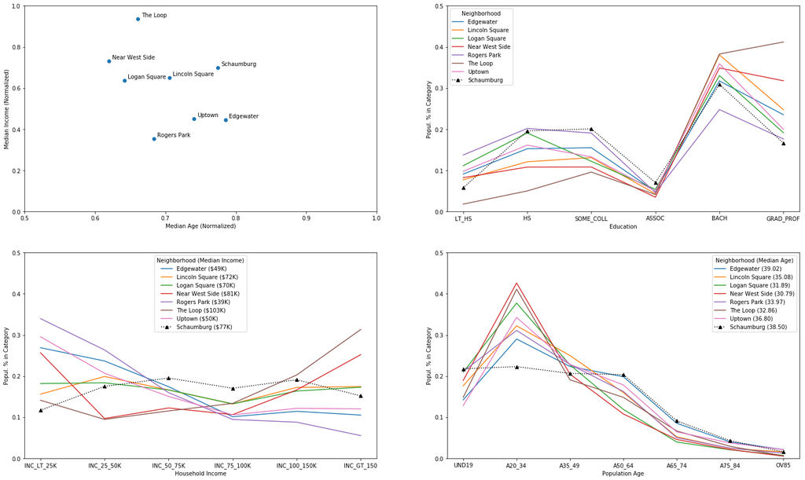

```python
plt.figure(figsize=(25,15))

plt.subplot(2,2,1)

x_val = (cluster_matches['MED_AGE'].div(demo_df['MED_AGE'].max()))
y_val = (cluster_matches['MEDINC'].div(demo_df['MEDINC'].max()))
plt.scatter(x_val,y_val)
plt.xlim(0.5,1)
plt.ylim(0,1)
plt.ylabel('Median Income (Normalized)')
plt.xlabel('Median Age (Normalized)')
for x, y, name in zip(x_val, y_val, cluster_matches.GEOG):
    plt.annotate(name, (x + 0.005, y + .01))



plt.subplot(2,2,2)

for index, row in cluster_matches.iterrows():
    plt.xticks(edu_ticks, edu_columns)
    if row['GEOG'] == 'Schaumburg':
        plt.plot(row[edu_columns],'^k:',label=row['GEOG'])
    else:
        plt.plot(row[edu_columns],label=row['GEOG'])
plt.ylim(0,0.5)
plt.ylabel('Popul. % in Category')
plt.xlabel('Education')
plt.legend(title='Neighborhood')

plt.subplot(2,2,3)

for index, row in cluster_matches.iterrows():
    plt.xticks(inc_ticks, inc_columns)
    short = row['MEDINC'] / 1000
    label = '{} (${:0.0f}K)'.format(row['GEOG'],short)
    if row['GEOG'] == 'Schaumburg':
        plt.plot(row[inc_columns],'^k:',label=label)
    else:
        plt.plot(row[inc_columns],label=label)
plt.ylim(0,0.5)
plt.ylabel('Popul. % in Category')
plt.xlabel('Household Income')
plt.legend(title='Neighborhood (Median Income)')

plt.subplot(2,2,4)

for index, row in cluster_matches.iterrows():
    plt.xticks(age_ticks, age_columns)
    label = '{} ({:.2f})'.format(row['GEOG'],row['MED_AGE'])
    if row['GEOG'] == 'Schaumburg':
        plt.plot(row[age_columns],'^k:',label=label)
    else:
        plt.plot(row[age_columns],label=label)
plt.ylim(0,0.5)
plt.ylabel('Popul. % in Category')
plt.xlabel('Population Age')
plt.legend(title='Neighborhood (Median Age)')

plt.show()
```

```python
chicago_venues_sorted[chicago_venues_sorted['Neighbourhood'].isin(list(cluster_matches['GEOG']))]
```

|  | Cluster Labels | Neighbourhood | 1st Most Common Venue | 2nd Most Common Venue | 3rd Most Common Venue | 4th Most Common Venue | 5th Most Common Venue | 6th Most Common Venue | 7th Most Common Venue | 8th Most Common Venue | 9th Most Common Venue | 10th Most Common Venue |
| --- | --- | --- | --- | --- | --- | --- | --- | --- | --- | --- | --- | --- |
| 21 | 4 | Edgewater | Coffee Shop | Italian Restaurant | Mexican Restaurant | Asian Restaurant | Sandwich Place | Breakfast Spot | Vietnamese Restaurant | Grocery Store | Sushi Restaurant | Burger Joint |
| 39 | 4 | Lincoln Square | Mexican Restaurant | Sushi Restaurant | Bakery | Coffee Shop | Vegetarian / Vegan Restaurant | Asian Restaurant | Grocery Store | Italian Restaurant | Gay Bar | Bar |
| 40 | 4 | Logan Square | Cocktail Bar | Coffee Shop | Café | Bar | Mexican Restaurant | Latin American Restaurant | Brewery | Pizza Place | Park | Ice Cream Shop |
| 48 | 4 | Near West Side | Italian Restaurant | Pizza Place | Coffee Shop | Yoga Studio | Breakfast Spot | Brewery | Sandwich Place | Café | Park | Deli / Bodega |
| 59 | 4 | Rogers Park | Beach | Sandwich Place | Mexican Restaurant | Pizza Place | Café | Fast Food Restaurant | Park | African Restaurant | Bakery | Bar |
| 61 | 4 | Schaumburg | Fast Food Restaurant | Grocery Store | Hotel | Hookah Bar | Pizza Place | Gym | Coffee Shop | Bakery | Korean Restaurant | Bookstore |
| 66 | 4 | The Loop | Theater | Coffee Shop | Hotel | Park | Pizza Place | Museum | Snack Place | Bakery | Sandwich Place | Salad Place |
| 67 | 4 | Uptown | Vietnamese Restaurant | Coffee Shop | Sushi Restaurant | Chinese Restaurant | Mexican Restaurant | Park | Grocery Store | Bar | Thai Restaurant | Breakfast Spot |

```python
demo_df[demo_df['GEOG'].isin(list(cluster_matches['GEOG']))][['GEOG','TOT_POP','MED_AGE','MEDINC']]
```

|  | GEOG | TOT_POP | MED_AGE | MEDINC |
| --- | --- | --- | --- | --- |
| 21 | Edgewater | 55965 | 39.022775 | 49287.01181 |
| 39 | Lincoln Square | 41715 | 35.079103 | 71736.93086 |
| 40 | Logan Square | 73046 | 31.885020 | 70338.93986 |
| 48 | Near West Side | 62872 | 30.789626 | 80727.42475 |
| 59 | Rogers Park | 55062 | 33.972649 | 39106.18280 |
| 65 | The Loop | 35880 | 32.859723 | 103336.27930 |
| 66 | Uptown | 57973 | 36.801845 | 49680.90452 |
| 77 | Schaumburg | 74427 | 38.500000 | 77022.00000 |

```python
latitude = 41.943
longitude = -87.858
loc_matched = locations_df[locations_df['GEOG'].isin(list(cluster_matches['GEOG']))]
map_matched = folium.Map(location=[latitude, longitude],zoom_start=12)

for lat, lng, neighborhood in zip(loc_matched['lat'], loc_matched['long'], loc_matched['GEOG']):
    label = folium.Popup(neighborhood, parse_html=True)
    folium.CircleMarker([lat,lng],
                       radius=5,
                       popup=label,
                       color='blue',
                       fill=True,
                       fill_color='#3186cc',
                       fill_opacity=0.7,
                       parse_html=False).add_to(map_matched)

map_matched
```

[interactive chart not shown]